# Project 2

This is the dataset you will be working with:

```r
olympics <- readr::read_csv('https://raw.githubusercontent.com/rfordatascience/tidytuesday/master/data/2021/2021-07-27/olympics.csv')

olympic_gymnasts <- olympics %>%
  filter(!is.na(age)) %>%             # only keep athletes with known age
  filter(sport == "Gymnastics") %>%   # keep only gymnasts
  mutate(
    medalist = case_when(             # add column for success in medaling
      is.na(medal) ~ FALSE,           # NA values go to FALSE
      !is.na(medal) ~ TRUE            # non-NA values (Gold, Silver, Bronze) go to TRUE
    )
  )
```

More information about the dataset can be found at https://github.com/rfordatascience/tidytuesday/tree/master/data/2021/2021-07-27/readme.md and https://www.sports-reference.com/olympics.html.

**Question:** Are there age differences for male and female Olympic gymnasts who were successful or not in earning a medal, and how has the age distribution changed over the years?

We recommend you use a violin plot for the first part of the question and faceted boxplots for the second question part of the question.

**Hints:**

- To make a series of boxplots over time, you will have add the following to your `aes()` statement: `group = year`.
- It can be a bit tricky to re-label facets generated with `facet_wrap()`. The trick is to add a `labeller` argument, for example:

```r
 + facet_wrap(
    # your other arguments to facet_wrap() go here
    ...,
    # this replaces "TRUE" with "medaled" and "FALSE" with "did not medal"
    labeller = as_labeller(c(`TRUE` = "medaled", `FALSE` = "did not medal"))
  )
```

**Introduction:** *Your introduction here.* The modern Olympic Games, a quadrennial event, have witnessed a plethora of athletes competing from various parts of the world. This dataset provides a comprehensive record of these athletes and their medal achievements from the inaugural Games in Athens 1896 to the recent one in Rio 2016. Each record encapsulates details about the athletes, such as their age, height, weight, and the events they participated in. Additionally, it offers insights into the specific Olympic Game, including its year, season, and host city. For the purpose of this analysis, we will primarily focus on the age, sex, medal, year, and sport columns to discern age differences among male and female Olympic gymnasts and their medal-winning trends over the years.

**Approach:** *Your approach here.* To address the question of age differences among male and female Olympic gymnasts based on their medal achievements, a violin plot will be employed. This plot type is adept at visualizing the distribution of data across different categories, making it ideal for comparing age distributions between medalists and non-medalists for male and female athletes. For the latter part of the question, which seeks to understand how the age distribution has evolved over the years for both male and female athletes, we will utilize faceted boxplots. These plots will be categorized by decades, allowing us to observe age trends over time. The facets will further distinguish between gymnasts who medaled and those who did not, providing a layered analysis.

**Analysis:**

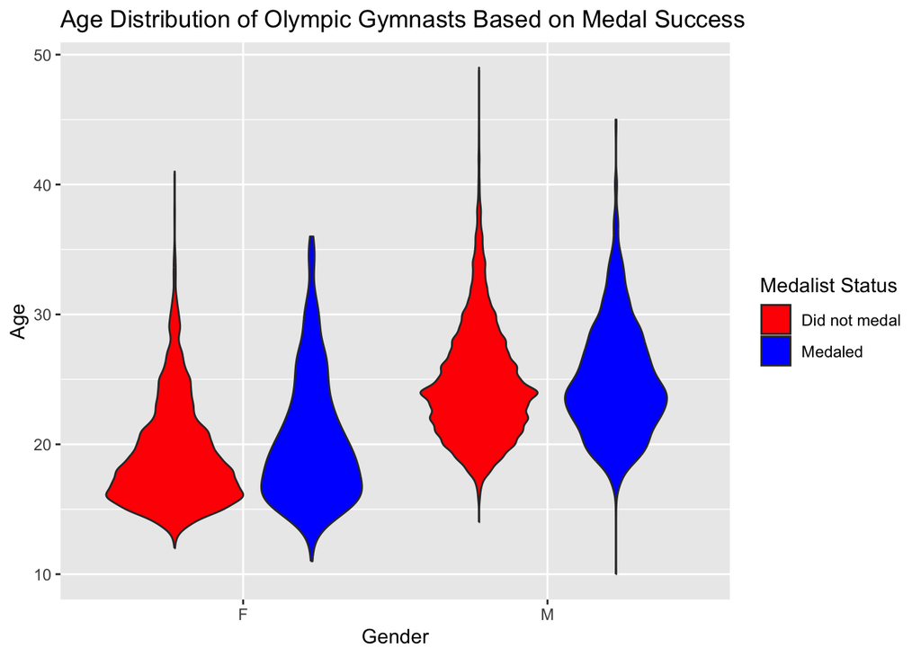

```r
# Your R code here
olympic_gymnasts %>%
  ggplot(aes(x = sex, y = age, fill = ifelse(medalist, "Medaled", "Did not medal"))) +
  geom_violin() +
  labs(title = "Age Distribution of Olympic Gymnasts Based on Medal Success",
       x = "Gender",
       y = "Age",
       fill = "Medalist Status") +
  scale_fill_manual(values = c("Medaled" = "blue", "Did not medal" = "red"))
```

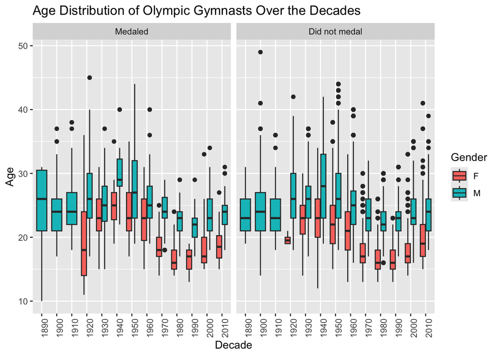

```r
# Data Wrangling: Group by Decades
olympic_gymnasts_wrangled <- olympic_gymnasts %>%
  mutate(decade = 10 * (year %/% 10),
         medalist = factor(medalist, levels = c(TRUE, FALSE), labels = c("Medaled", "Did not medal")))

# Faceted boxplots for age distribution over the decades by medalist status
olympic_gymnasts_wrangled %>%
  ggplot(aes(x = factor(decade), y = age, fill = sex)) +
  geom_boxplot() +
  facet_wrap(~medalist, scales = "free_x", labeller = as_labeller(c("Medaled" = "Medaled", "Did not medal" = "Did not medal"))) +
  labs(title = "Age Distribution of Olympic Gymnasts Over the Decades",
       x = "Decade",
       y = "Age",
       fill = "Gender") +
  theme(axis.text.x = element_text(angle = 90, hjust = 1))
```

**Discussion:** *Your discussion of results here.* The violin plot distinctly showcases the age distributions of male and female gymnasts in relation to their medal achievements. This visualization offers a clear perspective on the age brackets where gymnasts are predominantly securing medals, highlighting notable variations between the genders. Notably, male gymnasts tend to be older on average compared to their female counterparts. In contrast, the faceted boxplots present a temporal perspective on age trends within the gymnastics community. Over the years, female gymnasts have generally been younger than males. The age distribution has undeniably fluctuated over time, with specific periods like the 1980s displaying a younger median age for athletes, while the 1940s leaned towards an older median age. Such trends might be influenced by a myriad of factors, including shifts in training techniques, alterations in competition norms, or broader socio-cultural dynamics impacting the sport. A deeper dive into research would be instrumental in understanding the precise catalysts for these discerned patterns.